# Analyses for DIAG-NonParty-Radio

### Sample Characteristics

We collected data from a total of *N* = 389 participants using a Prolific representative sample that was stratified on the basis of age, sex, ethnicity, and political affiliation. Following our exclusion criteria we had to exclude 28 participants who inferred the wrong category in five or more non-target categorization items and one participant who rated their own data to be unfit for analysis. This resulted in *N* = 360 valid datasets (175 men, 180 women, 4 non-binary, 1 n/a; median age *Mdn* = 46 years, ranging from 19 to 79). 42% of participants identified as Democrats, 23% as Independents, 33% as Republicans, and 2% as other. According to Prolific demographics, more participants identified as Independents (31% Democrats, 42% Independents, 27% Republicans)–possibly because there was no “Independent” option in our survey. Participants received monetary compensation of 1.20 GBP for completing the 8-minute study. Participants’ mean political ideology was *M* = 54.6 (*SD* = 31.6), on a scale from 0 = conservative to 100 = liberal. 80 additional people started the experiment on prolific but returned their submission, timed-out, did not meet the inclusion criteria, or failed the comprehension check.

### Exclusion of Statistical Outliers

We did not preregister exclusion of statistical outliers. However, upon inspection of the data we noticed that there were many data points that were very unlikely to reflect valid categorizations. That is, some participants in both the stereotype-disconfirming and the stereotype-confirming condition seemed to infer categories from opinions that are stereotypically associated with the opposing category (e.g., inferring from a pro-gun control opinion that the person must be a Republican). We assume that such responses are likely due to the participants understanding the items the wrong way around or responding at random. To investigate the potential effect of these outliers we conducted additional analyses excluding them. Theoretically, any values below the scale midpoint (50) are very unlikely to reflect genuine categorizations, because they would indicate that the category that is not stereotypically associated with the opinion is more likely to express the opinion than the category that is stereotypically associated with it. While it would therefore seem appropriate to exclude any values below 50, we decided to exclude values below 40, to account for the fact that participants may respond somewhat inaccurately using the sliding scale. For the main analyses we report tests with and without this exclusion criterion.

A similar problem occurred for the stereotype measure on which some participants indicated that category members would on average strongly disagree with opinions that are stereotypical for their category. However, for this measure there is less of a clear cutoff, because even an opinion that is very stereotypical or diagnostic for a category must not be shared by a majority of its members (as long as it is shared by considerably less members of the opposing category). To nevertheless investigate the effect of these outliers we conducted a multiverse analysis using several different cutoff criteria.

### Manipulation Check

#### Stereotype Measure

##### Multiverse Outlier Correction

| cutoff | n excluded | DFn | DFd | ct_F | ct_p | ct_pes | typ_F | typ_p | typ_pes | int_F | int_p | int_pes |
| --- | --- | --- | --- | --- | --- | --- | --- | --- | --- | --- | --- | --- |
| none | 0 | 1 | 356 | 0.01 | .918 | .000 [.000, .003] | 3.32 | .069 | .009 [.000, .032] | 0.58 | .447 | .002 [.000, .016] |
| fixed 1 | 13 | 1 | 343 | 0.06 | .800 | .000 [.000, .008] | 7.62 | .006 | .022 [.004, .053] | 2.41 | .121 | .007 [.000, .029] |
| fixed 10 | 19 | 1 | 337 | 0.00 | .996 | .000 [.000, .000] | 7.01 | .009 | .020 [.003, .051] | 1.89 | .171 | .006 [.000, .026] |
| fixed 20 | 33 | 1 | 323 | 0.13 | .718 | .000 [.000, .011] | 10.81 | .001 | .032 [.008, .070] | 0.03 | .871 | .000 [.000, .006] |
| fixed 30 | 59 | 1 | 297 | 1.43 | .233 | .005 [.000, .026] | 6.71 | .010 | .022 [.003, .056] | 0.32 | .570 | .001 [.000, .016] |
| fixed 40 | 70 | 1 | 286 | 0.29 | .591 | .001 [.000, .016] | 5.85 | .016 | .020 [.002, .054] | 0.52 | .471 | .002 [.000, .019] |

To test whether the manipulation was successful, we conducted a multiverse analysis with multiple fixed outlier cutoffs. We excluded participants with values below 1, 10, 20, 30, or 40 and conducted a two-way between-subjects ANOVA with the stereotype measure as the dependent variable and typicality and category type as between-subjects factors. The effect of typicality was marginally significant with no outlier exclusion and significant with all different outlier thresholds. The effect of category type and the two-way interaction were not significant in any of the tests. These results provide moderate support for the effectiveness of our manipulation.

##### Outlier Detection

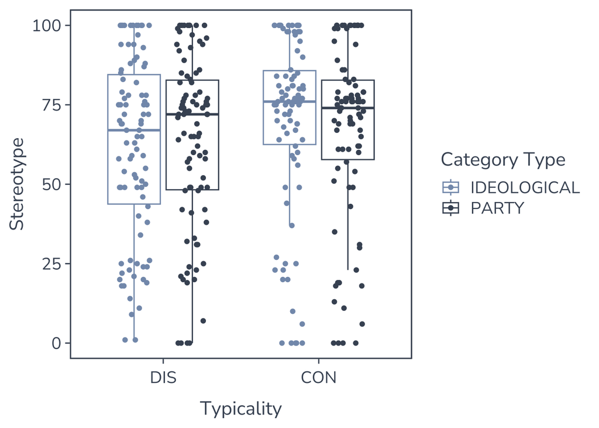

##### QQ-Plot

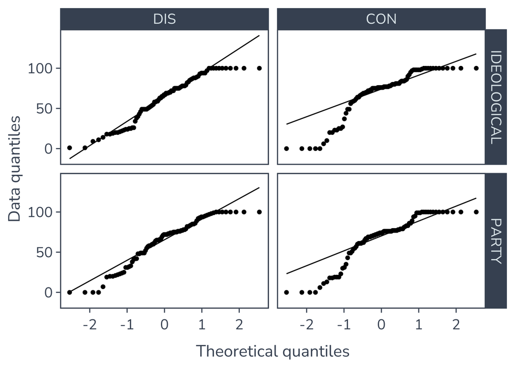

### Party Categorization

#### Counterstereotype Probability

For all of our analyses, we conducted one-sided independent samples *t* tests comparing political categorization in the stereotype-confirming and stereotype-disconfirming conditions. The tests for the counterstereotype probability condition were preregistered whereas the tests in the stereotype probability condition were exploratory. In the counterstereotype probability condition, the categorization into party categories was not significantly weaker when the stereotypes were disconfirmed (*M* = 77.6, *SD* = 19.6) as opposed to when they were confirmed (*M* = 81.4, *SD* = 20.9), *t*(177.22) = -1.27, *p* = .104, *d* = -0.19, 90% CI [-0.45, 0.050].

After excluding 9 participants with outlying values, political categorization was significantly weaker when the stereotypes were disconfirmed (*M* = 80.2, *SD* = 15.6) as opposed to when they were confirmed (*M* = 85.3, *SD* = 13.6), *t*(166.51) = -2.27, *p* = .012, *d* = -0.35, 90% CI [-0.62, -0.090].

##### Descriptives

| typicality | variable | n | mean | sd | ci95_low | ci95_upp |
| --- | --- | --- | --- | --- | --- | --- |
| DIS | inf | 90 | 77.600 | 19.569 | 73.55700 | 81.64300 |
| CON | inf | 90 | 81.422 | 20.913 | 77.10133 | 85.74267 |

##### Outlier Detection

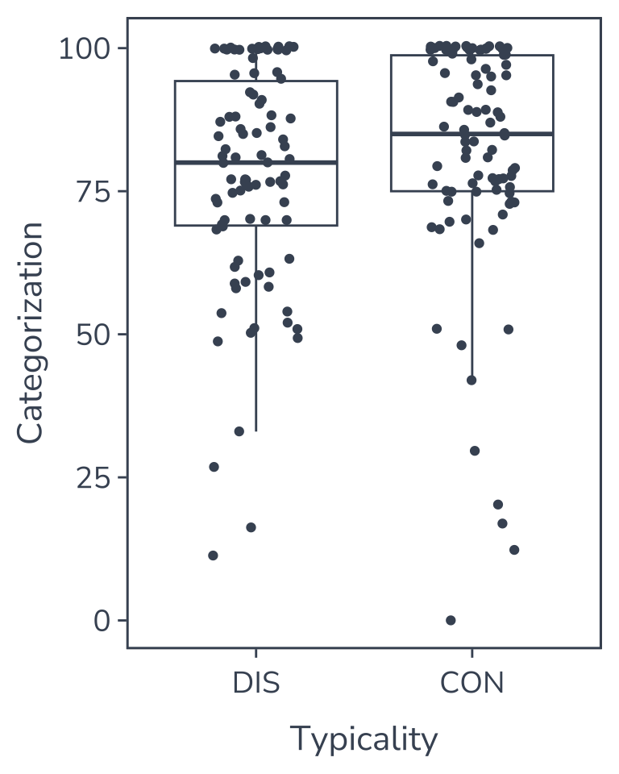

##### QQ-Plot

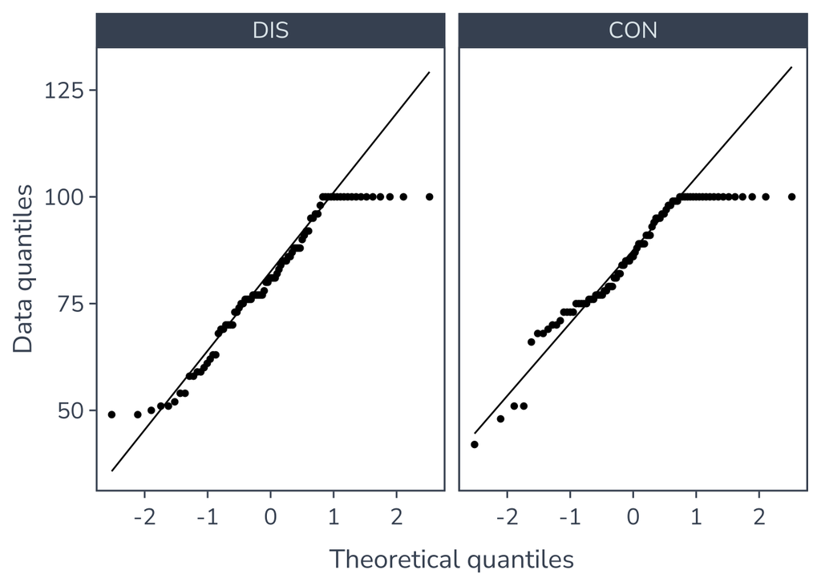

##### Moderation by partisan fit

| Effect | DFn | DFd | F | p | p<.05 | pes | 90% CI |
| --- | --- | --- | --- | --- | --- | --- | --- |
| partisan_fit | 1 | 122 | 0.00 | .976 |  | .000 | [.000, .000] |
| typicality | 1 | 122 | 6.32 | .013 | * | .049 | [.006, .121] |
| partisan_fit:typicality | 1 | 122 | 0.42 | .520 |  | .003 | [.000, .039] |

It may be possible that the effect of diagnosticity on political categorization depends on the fit between the participant’s party identification and the target’s partisanship. We therefore ran an exploratory analysis examining the role of ideological fit (i.e., whether participant and target belong to the same category or a different one). We excluded participants classified as Independents and conducted a two-way between-subjects ANOVA with political categorization as the dependent variable and ideological fit and typicality as between-subjects factors. We found a significant effect of typicality. All other effects were non-significant.

##### Moderation by political issue

| Effect | DFn | DFd | F | p | p<.05 | pes | 90% CI |
| --- | --- | --- | --- | --- | --- | --- | --- |
| issue | 2 | 165 | 2.54 | .082 |  | .030 | [.000, .075] |
| typicality | 1 | 165 | 5.53 | .020 | * | .032 | [.003, .086] |
| issue:typicality | 2 | 165 | 0.67 | .513 |  | .008 | [.000, .035] |

We ran another exploratory analysis to test whether the effect of diagnosticity on political categorization was moderated by the issue for which diagnosticity was manipulated. We conducted a two-way between-subjects ANOVA with political categorization as the dependent variable and issue and typicality as between-subjects factors. We found a significant effect of typicality. All other effects were non-significant.

#### Stereotype Probability

In the stereotype probability condition, the categorization into party categories was not significantly weaker when the stereotypes were disconfirmed (*M* = 80.2, *SD* = 22.2) as opposed to when they were confirmed (*M* = 80.4, *SD* = 24.5), *t*(176.35) = -0.064, *p* = .475, *d* = -0.010, 90% CI [-0.27, 0.24].

After excluding 15 participants with outlying values, political categorization was still not significantly weaker when the stereotypes were disconfirmed (*M* = 84.7, *SD* = 14.8) as opposed to when they were confirmed (*M* = 87.4, *SD* = 13.0), *t*(161.53) = -1.23, *p* = .110, *d* = -0.19, 90% CI [-0.43, 0.060].

##### Descriptives

| typicality | variable | n | mean | sd | ci95_low | ci95_upp |
| --- | --- | --- | --- | --- | --- | --- |
| DIS | inf | 90 | 80.222 | 22.219 | 75.63151 | 84.81249 |
| CON | inf | 90 | 80.444 | 24.485 | 75.38535 | 85.50265 |

##### Outlier Detection

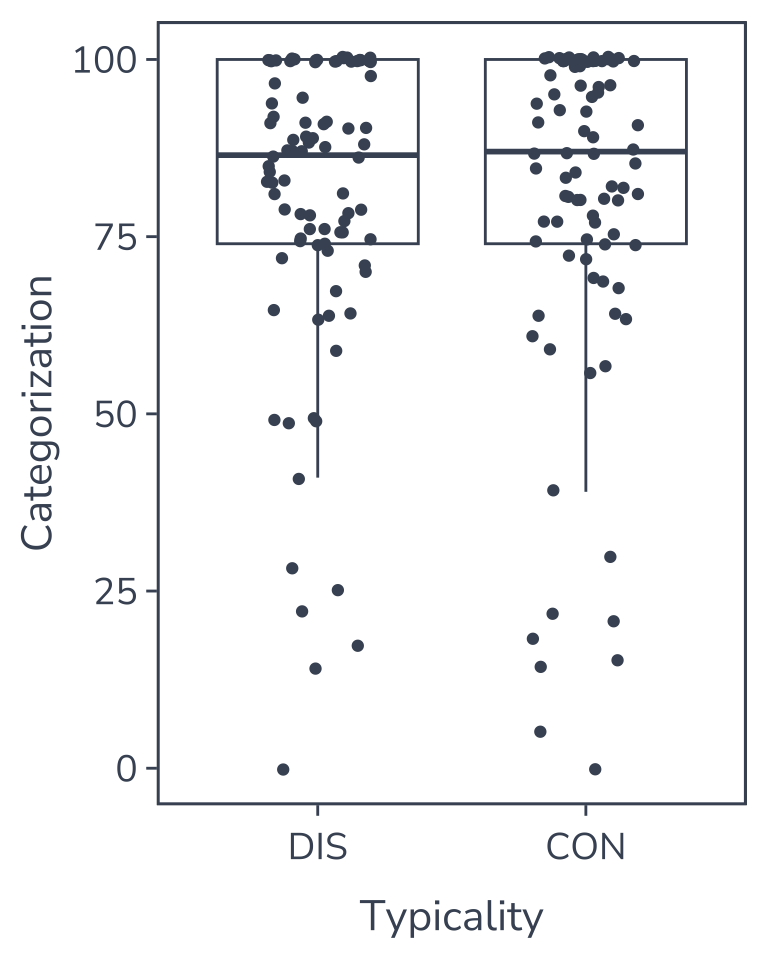

##### QQ-Plot

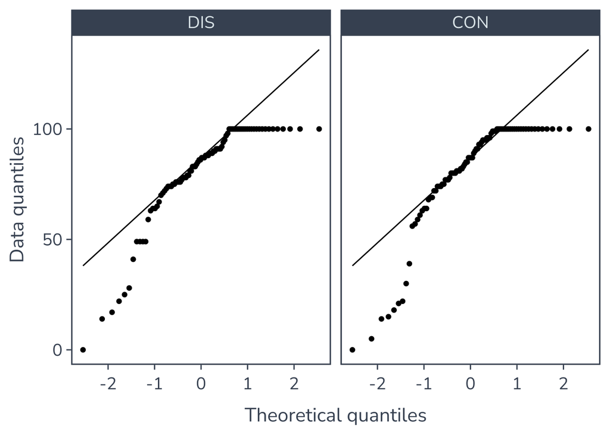

### Ideological Categorization

#### Counterstereotype Probability

In the counterstereotype probability condition, the categorization into ideological categories was not significantly weaker when the stereotypes were disconfirmed (*M* = 79.0, *SD* = 17.4) as opposed to when they were confirmed (*M* = 81.7, *SD* = 20.4), *t*(173.75) = -0.96, *p* = .168, *d* = -0.14, 90% CI [-0.40, 0.090].

After excluding 8 participants with outlying values, political categorization was significantly weaker when the stereotypes were disconfirmed (*M* = 80.1, *SD* = 16.0) as opposed to when they were confirmed (*M* = 86.0, *SD* = 12.9), *t*(165.59) = -2.66, *p* = .004, *d* = -0.41, 90% CI [-0.67, -0.15].

##### Descriptives

| typicality | variable | n | mean | sd | ci95_low | ci95_upp |
| --- | --- | --- | --- | --- | --- | --- |
| DIS | inf | 90 | 79.022 | 17.417 | 75.42361 | 82.62039 |
| CON | inf | 90 | 81.744 | 20.391 | 77.53118 | 85.95682 |

##### Outlier Detection

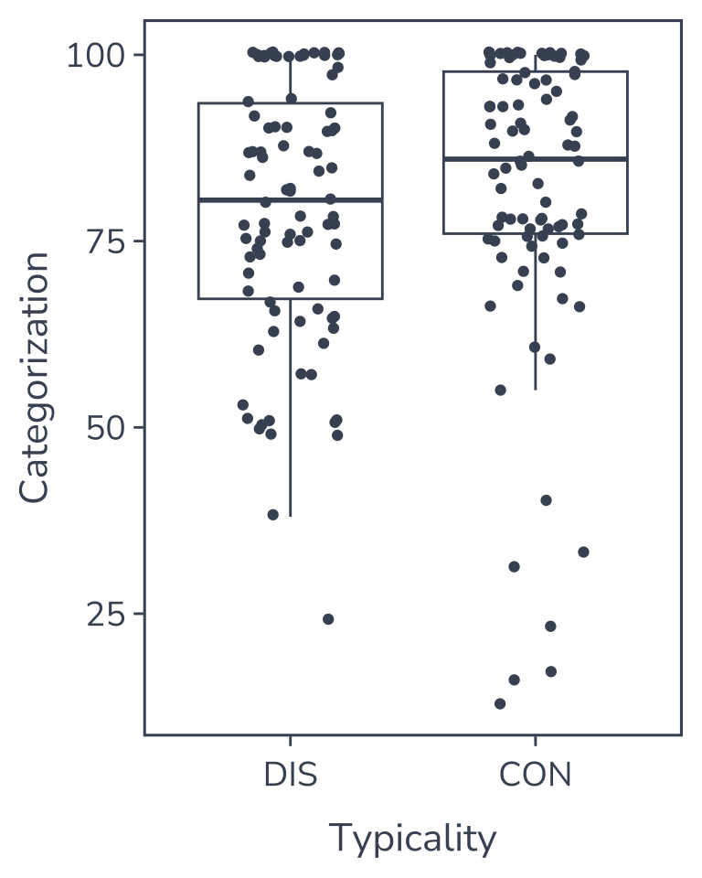

##### QQ-Plot

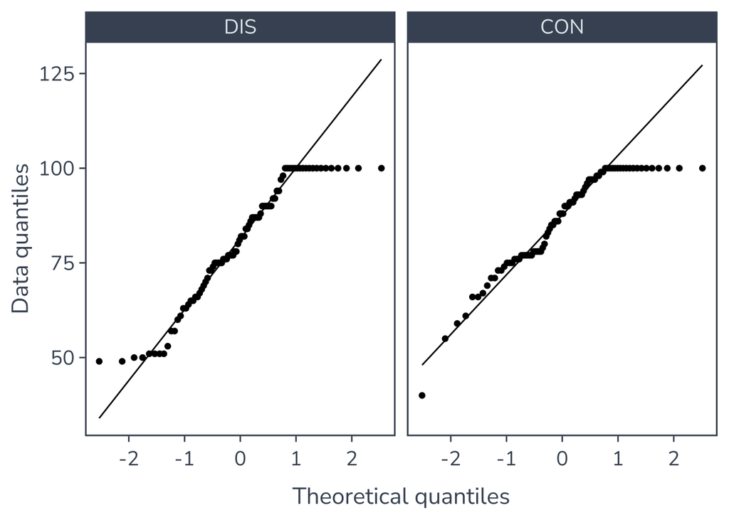

##### Moderation by ideological fit

| Effect | DFn | DFd | F | p | p<.05 | pes | 90% CI |
| --- | --- | --- | --- | --- | --- | --- | --- |
| ideo_fit | 1 | 111 | 0.66 | .420 |  | .006 | [.000, .050] |
| typicality | 1 | 111 | 2.20 | .140 |  | .019 | [.000, .079] |
| ideo_fit:typicality | 1 | 111 | 0.78 | .378 |  | .007 | [.000, .053] |

It may be possible that the effect of diagnosticity on political categorization depends on the fit between the participant’s ideological category and the target’s category. We therefore ran an exploratory analysis examining the role of ideological fit (i.e., whether participant and target belong to the same category or a different one). We excluded participants classified as moderates and conducted a two-way between-subjects ANOVA with political categorization as the dependent variable and ideological fit and typicality as between-subjects factors. None of the effects were significant.

##### Moderation by political issue

| Effect | DFn | DFd | F | p | p<.05 | pes | 90% CI |
| --- | --- | --- | --- | --- | --- | --- | --- |
| issue | 2 | 166 | 6.42 | .002 | * | .072 | [.016, .133] |
| typicality | 1 | 166 | 7.59 | .007 | * | .044 | [.007, .102] |
| issue:typicality | 2 | 166 | 0.79 | .455 |  | .009 | [.000, .038] |

We ran another exploratory analysis to test whether the effect of diagnosticity on political categorization was moderated by the issue for which diagnosticity was manipulated. We conducted a two-way between-subjects ANOVA with political categorization as the dependent variable and issue and typicality as between-subjects factors. We found a significant effect of issue that was likely driven by weaker categorization in the affirmative action condition. Moreover, we found a significant effect of typicality. The interaction was not significant.

#### Stereotype Probability

In the stereotype probability condition, the categorization into ideological categories was not significantly weaker when the stereotypes were disconfirmed (*M* = 76.8, *SD* = 20.9) as opposed to when they were confirmed (*M* = 81.2, *SD* = 19.4), *t*(177.09) = -1.46, *p* = .074, *d* = -0.22, 90% CI [-0.46, 0.040].

##### Descriptives

| typicality | variable | n | mean | sd | ci95_low | ci95_upp |
| --- | --- | --- | --- | --- | --- | --- |
| DIS | inf | 90 | 76.789 | 20.881 | 72.47494 | 81.10306 |
| CON | inf | 90 | 81.167 | 19.433 | 77.15210 | 85.18190 |

##### Outlier Detection

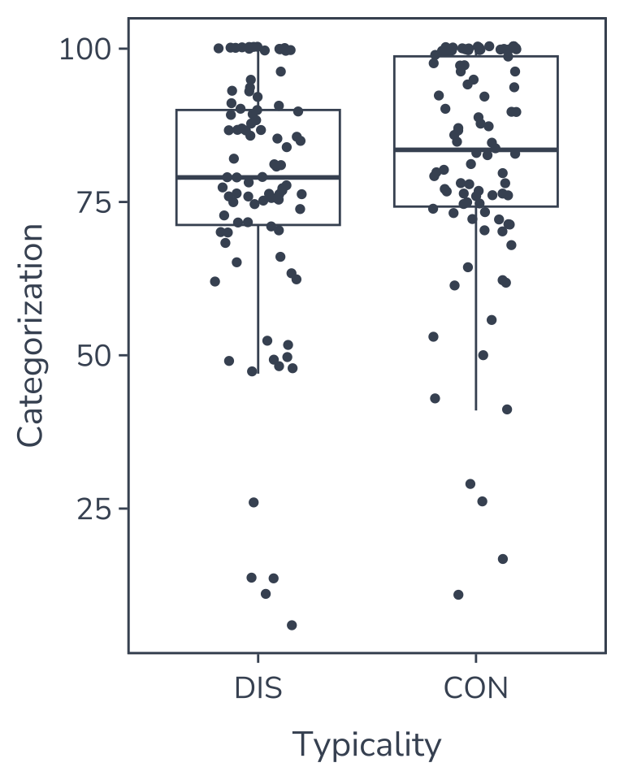

##### QQ-Plot

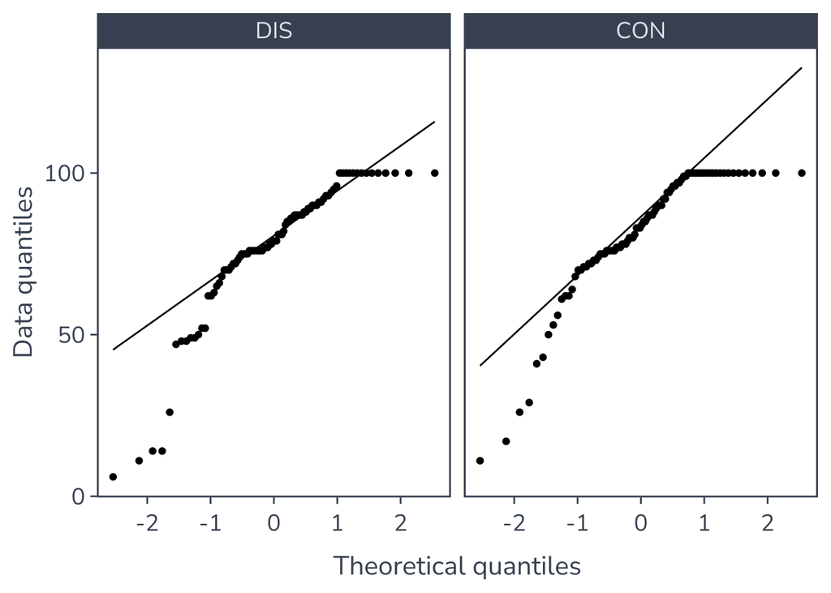